# Lecture 19b Methods Practice

Nick Huntington-Klein

March 20, 2019

## Recap

- We’ve been going over ways in which we can isolate causal effects
- We can select similar control groups using matching or controlling (what economists call “selection on observables”)
- We can use a group at a different time as its own control with fixed effects
- Or, “natural experiments”:
- When a treatment is applied at a particular time, we can select a reasonable control to account for the effects of time using difference-in-difference
- When the treatment is assigned according to a cutoff in a running variable, we can use regression discontinuity

## Today

- We’re going to be trying to *apply* these methods
- Given a real-world causal statement, how can we go about selecting a method?
- We can follow the steps we’ve been taking all along!

## Our Approach

1. Consider the problem
2. Think about what we think the *data-generating process* is
3. Draw a diagram
4. Figure out the method (we may have to control for some things for the usable diagram to emerge!)
5. Actually implement the method

## Think about the Data-Generating Process

- Our example from last time was corporate social responsibility
- We think that CSR might affect stock prices, and we know that CSR resolutions are taken up by winning vote
- Of course, the vote share might be related to a million different things about the company, or about the company at that time

## Draw a Diagram

- `comp` is “company”, `c.t` is company at a particular time

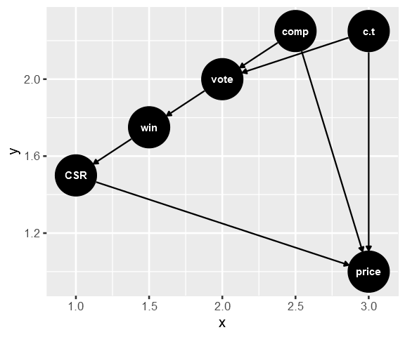

## Figure out a Method

- What back doors do we have? (`CSR <- win <- vote <- comp/c.t -> price`)
- Can we measure enough variables to control/match to close them all?
- Are they all individual-level or time-level variables so that we can do a diff-in-diff with panel data?
- Do we have a running variable and assign the treatment with a cutoff so we can do regression discontinuity?

## Implement the Method

```r
#I don't actually have this data but we can pretend
data(CSRdata)

bandwidth <- .02
cutoff <- .5
CSRdata %>%
  #Limit to just the area around the cutoff
  filter(abs(vote - cutoff) < bandwidth) %>%
  #Then, compare winning votes to losing votes
  mutate(win = vote > cutoff) %>%
  group_by(win) %>%
  summarize(price = mean(price))
```

## Let’s do More

- Let’s focus on the topic of real importance:
- How can we build a research design based on our causal question of interest and what we know about the world?
- I have five questions and topics, let’s work together to build diagrams and pick a research design
- Don’t look ahead in the slides!

## Fishery Sustainability

- We don’t want to overfish the oceans! However, common economic logic dictates that fish stocks are a “common good” likely to be overharvested if without restrictions
- One way of restricting fishing is to implement a transferable quota (ITQ) - a “cap and trade” basically
- This limits the allowable catch, and by allowing people to trade their allotment, ensures that the most efficient boats do the catching
- But does it work? Does `ITQ` affect next year’s fishing `stock`?

## Fishery Sustainability

Draw the diagram! To consider:

- Some countries implement ITQs, others don’t. We can observe countries both before and after the ITQ
- Certain characteristics of the country, like size, coastline, politics, etc., might be related to the decision to implement
- ITQ doesn’t affect `stock` directly, but by reducing this year’s `catch`
- The global economy changes over time, and affects fish demand and thus `catch`

## Fishery Sustainability

`coun` = country characteristics, `econ` = world economy

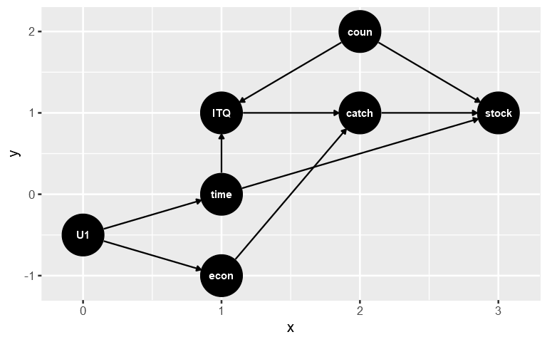

## Financial Reports

- Do financial statements, required to be released annually, affect a firm’s stock price?
- You might expect them to! After all, this contains important information about the company
- But maybe not - these reports just say what the company’s financial health is, and investors paying attention may already know that so it would already be baked into the price.
- What is the effect of the financial `rep`ort on stock `price`?

## Financial Reports

Draw the diagram! To consider:

- The govt requires `rep`orts be released at a certain `time`, so there’s a particular time at which the report goes from being unknown to known
- A firm’s `health` will change over time and also affect the `price`
- The overall `econ`omy will also change over time, and affect firm health
- Firm health is too complex to be measured and controlled for

## Financial Reports

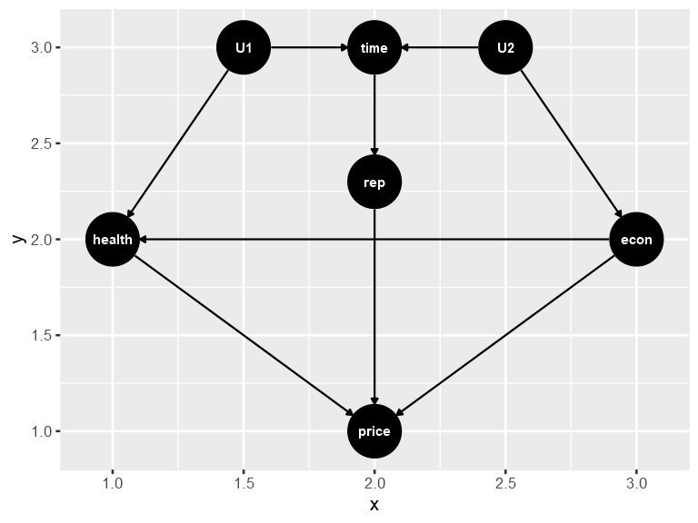

## Financial Reports

- This is a case for a regression discontinuity with `time` as the running variable
- When an RDD uses `time` as a running variable it’s called an “interrupted time series”
- Generally not considered quite as trustworthy as other RDDs, since it’s more likely that other stuff changes across the before/after barrier than across the below cutoff/above cutoff barrier

## Medicare and Retirement

- Does having health insurance encourage you to take more risks? Like quitting your job?
- Many people in the US get health insurance through their employer and have no realistic way of paying for it otherwise
- At age 65 you become eligible for Medicare
- Does Medicare make people quit their jobs?

## Medicare and Retirement

Draw a diagram! To consider:

- You become eligible for `med`icare at exactly the day you `turn65`.
- Your overall age, and your decision to `quit`, may be related in different ways to many things like `race`, `gen`der, before-age-65 `health`, and `inc`ome. Some of these things may also affect each other
- Your `inc`ome may also determine whether or not you choose to use Medicare (or go with something private instead)

## Medicare and Retirement

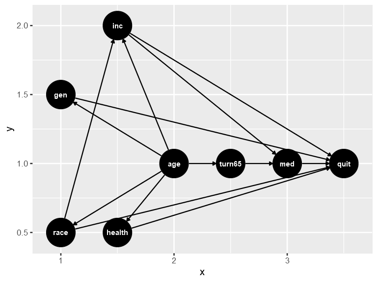

## Medicare and Retirement

- Regression discontinuity again, this time with age as running variable
- Lots of back doors! But no need for controls, the RDD isolates just our path of interest here
- As long as the treatment is “turning 65” - if the treatment is “receives Medicare” we still need to control for income - why?
- Note: how can age “cause” race or gender? Why, differential mortality rates of course!

## Monetary Policy

- A standard economics result is that monetary policy - putting more money into the economy, which the Federal Reserve does by buying treasury bonds (“monetary policy”) - leads to more inflation
- Of course, there might be other reasons why we see monetary policy linked to inflation
- Perhaps, for example, the kinds of things that make the Fed respond by buying bonds happen to lead to inflation on their own?

## Monetary Policy

Draw a diagram! To consider:

- Buying/selling bonds (monetary policy, `MP`) changes the amount of `money` in the economy
- Inflation comes from the amount of money there is relative to the amount of *stuff* there is, which comes from economic `prod`uctivity and `unemp`loyment
- Money in the economy is also affected by the amount of money tied up in `inv`estments
- And your `coun`try characteristics affect everything too!

## Monetary Policy

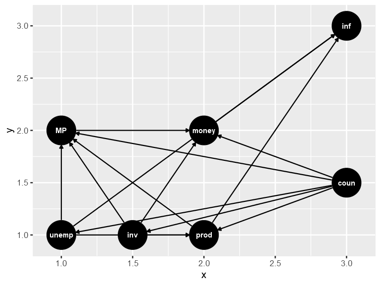

## Monetary Policy

- For this one we need lots of controls!
- We have back doors through `unemp`, `inv`, `prod`, and `coun`
- So we control for all of them with controlling or matching. For `coun` we need fixed effects.

## The Minimum Wage

- A classic causal question is “what is the effect of the minimum wage on employment?”
- Principles of econ classes point out that raising the minimum wage (like raising the price on anything) should reduce the number of people employed
- However there are other wrinkles: what if people take that money and spend it, improving the economy and increasing employment that way-
- Or what if the labor market isn’t competitive, meaning that increasing wages might actually encourage more employment?

## The Minimum Wage

Draw a diagram! To consider:

- In 1992 (i.e. in a certain `year`), New Jersey increased their `MW` from $4.25 to $5.05
- Neighboring Pennsylvania didn’t. So the `MW` differs by `state`
- We can look at fast food restaurants (most likely to be affected) just around the border
- It’s possible that the two states had different `trends` in terms of how their labor markets were changing
- The national `econ`omy might have also had an effect on `unemp`loyment
- What is the effect of the `MW` increase on `unemp`loyment?

## The Minimum Wage

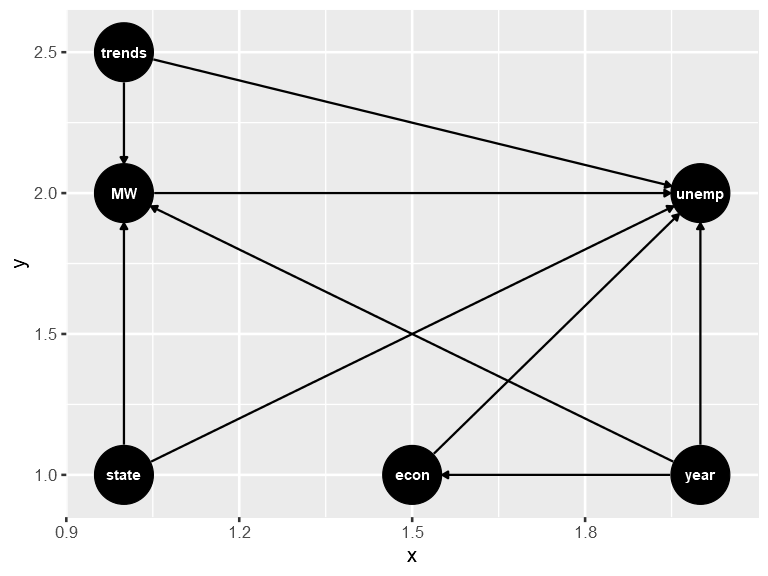

## The Minimum Wage

- A good spot for difference-in-differences!
- We need to control for `trends` too - DID won’t handle that on its own as it has to do with changes in the gap BETWEEN the two states over time.
- No need to control for `econ` - the DID adjustment for `year` handles that back door